# Pretty tables and plots

### Simple histogram

Let’s start with a simple histogram of movie ratings from the `movie_data` dataset. Something like this:

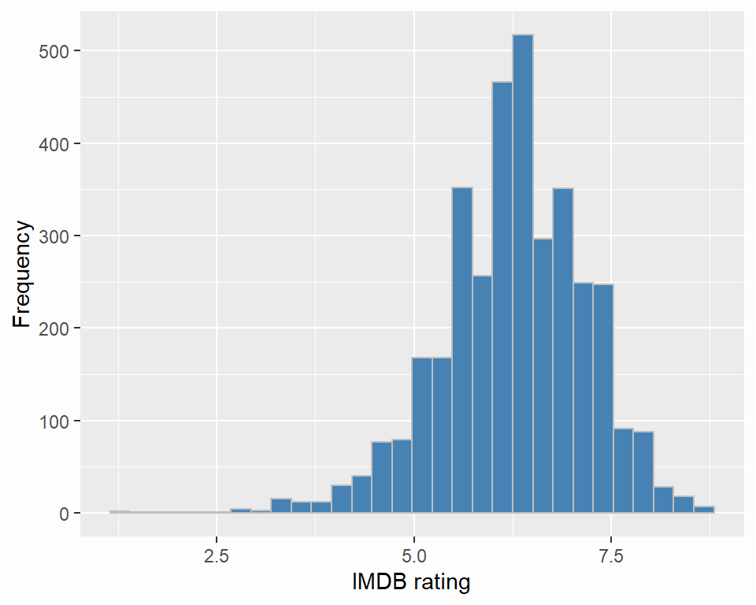

The code to build this plot is really simple. The reason why this is a Prog-rocK task is that the logic of building it up layer by layer will feel a little unfamiliar at first. Don’t worry though, we’ll do this together, step-by-step.

First, it might be useful to see the sequences of layers we’ll be creating and then we’ll look at the code that makes them. These are the steps we need to take:

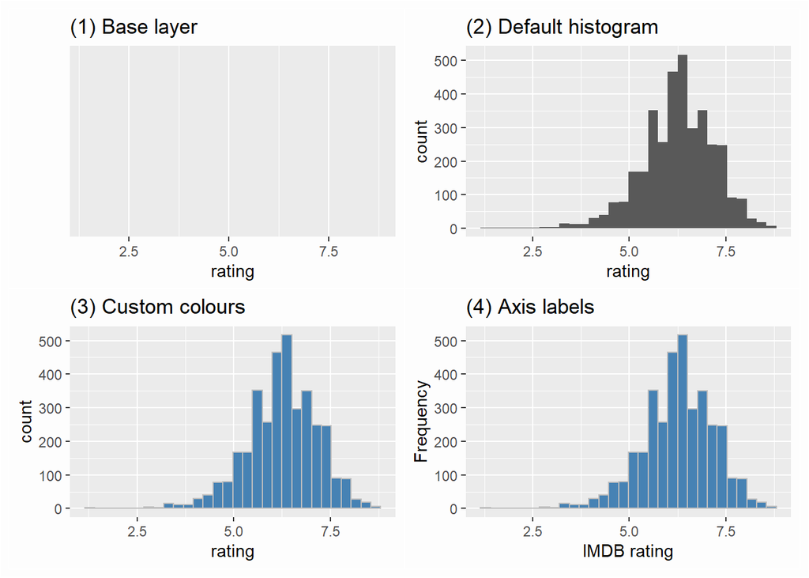

In **step (1)**, we create the base layer with the `ggplot2::ggplot()` function. This is where we tell the plotting function what our data are and what variables we want to *map* to the plot axes.

Variables/objects mapped onto plot elements are called **aesthetics** in the `ggplot2` terminology. This is an important term and we’ll be using it a lot so remember it. To map a variable as an aesthetic, we need to use the `aes()` function. We’ll demonstrate this next

For now, just remember, whenever you want anyting on the plot to behave in a way that’s *dependent on a variable in your data*, you need to **map that variable as an aesthetic** using the `aes()` function.

So the base layer consists of a `ggplot2::ggplot()` function with the `movie_data` object as its data and the `rating` variable **mapped as an aesthetic** onto the x-axis. Complete the code in the `base-layer` code chunk according to these principles.

```r
p1 <- movie_data %>%
  ggplot2::ggplot(data = ., aes(x = rating))
```

As you can hopefully see when you run the command, the `p1` (for “plot layer 1”) object now contains the first layer – the plotting region – with the `rating` variable mapped onto its x-axis. There’s nothing on the y-axis, because we’re making a histogram and that is a univariate plot: it shows the distribution of one variable.

Once you’ve mapped a variable as an aesthetic (using the `aes()` function) in the `ggplot2::ggplot()` layer, it will get passed down to all the subsequent layers of the plot so you don’t have to specify it again.

**Step (2)** of our 4-step plot creates a *“geometry”*, that’s shapes to you and me. It’s good to remember this term as is makes it clear why all the `ggplot2` functions that create shapes are called `geom_` something or another. For instance, to create a histogram geometry, we just add a `geom_histogram()` layer. Individual plot layers in `ggplot2` are added with a simple `+`.

Try it yourself! Just add the `geom_histogram()` to `p1` in the `geom-layer` code chunk. No arguments are needed…

```r
p2 <- p1 + # you can break line after each + if you want
  geom_histogram()
```

Let’s pause to notice a couple of things. Firstly, `ggplot2` has labelled both axes for you. It took the x-axis label from the variable you mapped as aesthetic onto the axis. “Count” is the default label for the y-axis of a histogram.

Secondly, it chose reasonable axis ranges: the x-axis spans the range 1-9, while y-axis ranges from 0 to 550. These make total sense given the data we have. In case you’re wondering, yes you can change the ranges to anything you want but there’s not often need for that as `ggplot2` does a pretty good job choosing sensible axes.

Okay, let’s move on to **step (3)**, where we add custom colours to the `geom_histogram()` layer. In the previous step, we didn’t give the function any arguments because, technically, we don’t need to if we’re happy with the default settings. But it’s good to know about at least the basic ones.

The arguments `colour=` (`color=` also works) and `fill=`, which govern the colour of the outline and the inside of a shape, respectively, can be given to *any geom layer*. Now, some shapes, such as lines, empty circles, or small points, don’t have “an inside”, in which case you shouldn’t try specifying the `fill=` argument but in the case of a histogram, the bars can have both an outline and a fill colour.

There are multiple ways of specifying a colour in `R` but the simplest one is using any of the recognised colour names. The plot above has the colour `"grey"` as the outline colour of the bars and the fill colour is `"steelblue"`. You can use these or pick your own. If you’d like to know which names are valid, look up “color names in ggplot2” or something like that…

Modify the code you wrote in the `geom-layer` code chunk, giving some colour names to the `colour=` and `fill=` arguments of the `geom_histogram()` function.

Remember that individual arguments must be separated with a comma and that `character` stings must be quoted.

```r
p2 <- p1 +
  geom_histogram(colour = "grey", fill = "steelblue")
```

That looks nicer, doesn’t it?

Finally, we move on to **step (4)**, where we give the axes custom labels. You might think that it would make sense to set axis labels inside the base layer function and you wouldn’t be wrong. However, in the `ggplot2` philosophy, axis labels are specified in a layer (or layers) of their own. Just like with most things in `R`, there are several ways of setting axis labels but the most straightforward one is to add a `labs()` layer that takes two arguments, `x=` and `y=` (both need to be `character` strings).

In the `labs-layer` code chunk, create a plot with nicer axis labels.

And that’s it: That’s out histogram!

Let’s recap the basics of `ggplot2`:

- There must be a base `ggplot2::ggplot()` layer where you specify what the data are and where you **map variables as aesthetics** to axes (or other plot elements)
- further layers are added with `+`
- Next, you add one or more layers of shapes or *geometries*, each using a `geom_[something]()` function.
- You may provide optional arguments to the `geom_` functions to change the colour, shape, size, fill *etc.* of the particular layer.
- Axis labels and other modifications are added in separate layers

Notice that, when specifying colour and fill of the histogram bars, we didn’t use the `aes()` function. That is because we weren’t mapping variables to these characteristics of our plot; we were simply setting their values.

The `aes()` function is **only for mapping variables** (columns of datasets) onto plot characteristics. If you are hard-setting these characteristics by giving them specific values, you must not use `aes()`!

### Scatter plot

Now that you are beginning to understand how `ggplot2` works, making simple plots should start feeling relatively straight-forward.

Take this scatter plot of penguin flipper length and beak length:

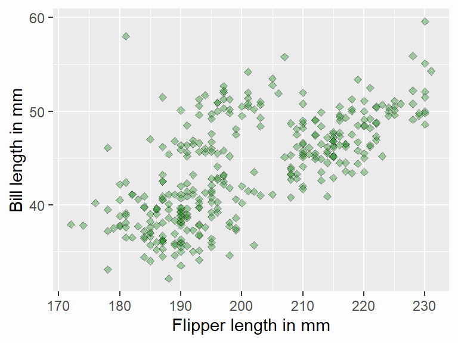

The plot is constructed in very much the same way as the histogram we just made. There are only two differences:

- Scatter plots are *bivariate* plots and so you need to map 2 variables as aesthetics, one for the x-axis, one for the y-axis.
- Obviously, we won’t be using `geom_histogram()` because it’s, well… not a histogram. Instead, the geometry we need is `geom_point()`.

Try creating the plot in the `scatterplot` chunk.

To make the plot look a little less crowded, you can add some transparency to the points using the `alpha=` argument to `geom_point()`. The argument takes values from 0 to 1, with 0 meaning full transparency (points won’t be visible) and 1 meaning full opacity.

Edit the chunk, adding transparency of, say, 0.4.

```r
palmerpenguins::penguins %>%
  ggplot2::ggplot(data = .,
                  aes(x = flipper_length_mm, y = bill_length_mm)) +
  geom_point(alpha = .4) +
  labs(x = "Flipper length in mm", y = "Bill length in mm")
```

You can also change the shape of the plotted points with the `shape=` argument. The argument takes an integer, where each value represents a different shape or symbol. It’s best to stick with values between 1 and 25, as higher numbers stand for letters and other non-point symbols. Some shapes can only accept the `colour=` argument (shapes 1-20), while others – like the one in the plot we’re building – can take both `colour=` and `fill=` arguments for outline and fill, respectively (shapes 21-25).

If you want to know what shapes the values 1-25 represent without having to try them all out, just look up “ggplot point shapes” or something similar.

Out plot uses shape 23 (filled diamonds) filled with the “forestgreen” colour. Edit the code chunk to add these arguments.

```r
palmerpenguins::penguins %>%
  ggplot2::ggplot(data = .,
                  aes(x = flipper_length_mm, y = bill_length_mm)) +
  geom_point(alpha = .4, shape = 23, fill = "forestgreen") +
  labs(x = "Flipper length in mm", y = "Bill length in mm")
```

That is a reasonably good-looking plot! However, just like all the plots we’ve made so far, it’s missing one important element…

### Adding a caption

All plots should have captions. Luckily, adding them is pretty easy, although it’s not done in the same way as with tables. There is no `caption=` argument to `ggplot()` this time. Instead, you need to specified an option for the code chunk.

We haven’t really talked about chunk options all that much yet so we won’t go into details just now. All you need to do is add a bit of text to the top fence of the code chunk that creates your plot:

````
```{r, fig.cap="Figure X. A descriptive figure caption}
````

Unfortunately, you have tonumber the figures manually. There is a way of having R Markdown take care of figure numbering but that’s an advanced topic that’s outwith[^2] the scope of this practical.

#### Changing plot size

While we’re talking about chunk options, there are two more options that are both handy and very easy to use: `fig.height=` and `fig.width=`. You will surely be able to guess what these are for. Feel free to play around with them, trying different numeric values and see how the size of your plots changes. For reference, Fig. 3 below has the options set to `fig height = 3, fig.width = 4`.

### Grouped scatter plot

The past two tasks were rather breezy so let’s step up our `ggame` and learn something cool.

Have a look at the plot below:

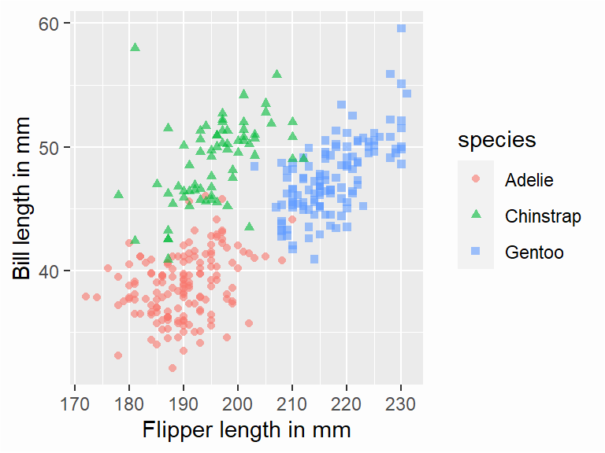

Figure 3. A groupped scatter plot of flipper vs bill length by penguin species

As you can see, the points have both a different colour and a different shape for each of the three species of penguins in the data set. Now, we’ve talked about how you mustn’t use the `aes()` function when you’re giving a fixed value to a plot element (such as size, shape, colour, fill, alpha…). We also talked about how variables can be mapped onto plot elements as aesthetics using the `aes()` function. Putting these two together, we can map a variable, in this case `species` onto both `shape=` and `colour=` but if we do that, we **must map it as an aesthetic**. It’s very similar to how you mapped variables onto axes.

Try to figure out how to do this with a little hint in the `grouped-scatterplot` code chunk.

```r
palmerpenguins::penguins %>%
  ggplot2::ggplot(
    data = .,
    aes(x = flipper_length_mm,
        y = bill_length_mm,
        shape = species,
        colour = species)) +
  geom_point(alpha = .6) +
  labs(x = "Flipper length in mm", y = "Bill length in mm")
```

As a bonus, the legend gets added automatically. That’s a pretty neat way of creating relatively complex plots and, once you get the principles of what does and doesn’t go inside `aes()`, it actually makes sense! Just remember:

You can map any variable onto pretty much any argument (`size=`, `shape=`, `alpha=`, `colour=`, `fill=`, *etc*.

If you’re mapping a variable from your data set onto these, **the expression needs to be inside the `aes()` function**, for instance `aes(shape = height_cm)`.

If, however, you’re only giving these arguments fixed values, such as `shape = 21`, **do not use `aes()`**!

Before you move on, don’t forget to give the plot an informative caption by providing a character string to the `fig.cap=` chunk option.

### Violin-box plot combo

As mentioned earlier in the worksheet, you can layer up as many `geoms` as you want. This is very simple as, if you map your aesthetics in the base `ggplot2::ggplot()` layer, all other layers will “inherit” them.

Try building this violin plot with inlaid boxplots from scratch in the `viol-box` code chunk. Once again, the data come from the `palmerpenguins::penguins` data set.

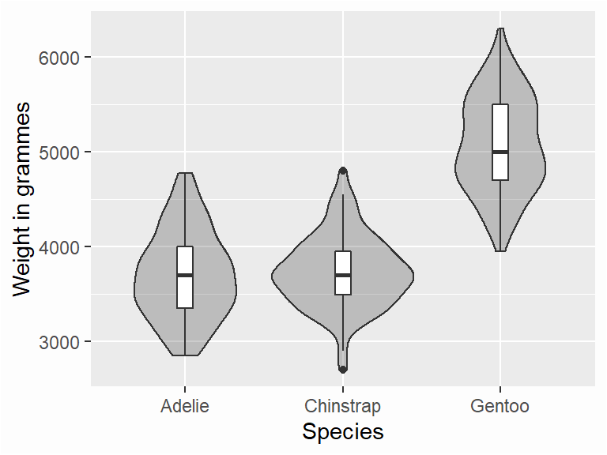

Figure 4. A violin plot of specimen weight by species with inlaid boxplots

The individual `geom_` functions are named pretty reasonably, so even if you have never used one, you can try your intuition and guess the name. If that fails, you can always look up something like “violin plots in ggplot2” and so on. Being able to use online resources is very important when it comes to coding and data analsyis.

The plot above has the “violins” filled black with a lot of transparency and the boxes are made narrower using the `width=` argument with a value of less than 1. Sometimes, you just have to try different values to see what looks good…

Don’t forget to add a caption!

```r
palmerpenguins::penguins %>%
  ggplot2::ggplot(data = ., aes(x = species, y = body_mass_g)) +
  geom_violin(fill = "black", alpha = .2) +
  geom_boxplot(width = .1) +
  labs(x = "Species", y = "Weight in grammes") + bg
```

### Changin plot themes

Let’s talk briefly about how we can change the overall appearance of the plot.

This is done in line with the layering philosophy of `ggplot2`. The `theme` layer can be used to change pretty much any detail of the plot layout or background. The `theme()` function is really big – it can take more than 95 optional arguments – so we won’t really delve into it much. Instead, you can easily set the style of the plot to one of the pre-defined themes.

Add another layer to the violin plot. Type `theme_` and wait for the list of possible themes to pop up (if it doesn’t try pressing the `⭾ Tab` key). Feel free to try out different themes. `theme_light()`, `theme_bw()`, `theme_classic()` are all pretty nice.

There are also extra themes you can install with packages to make your plots look like the ones on the [BBC](https://bbc.github.io/rcookbook/) or in [The Economist](https://rdrr.io/cran/ggthemes/man/theme_economist.html), if that’s your thing…

### Grouped violin plot (custom colours)

Let’s add a few tricks to our arsenal of `ggplot2` skills!

Have a look at this plot:

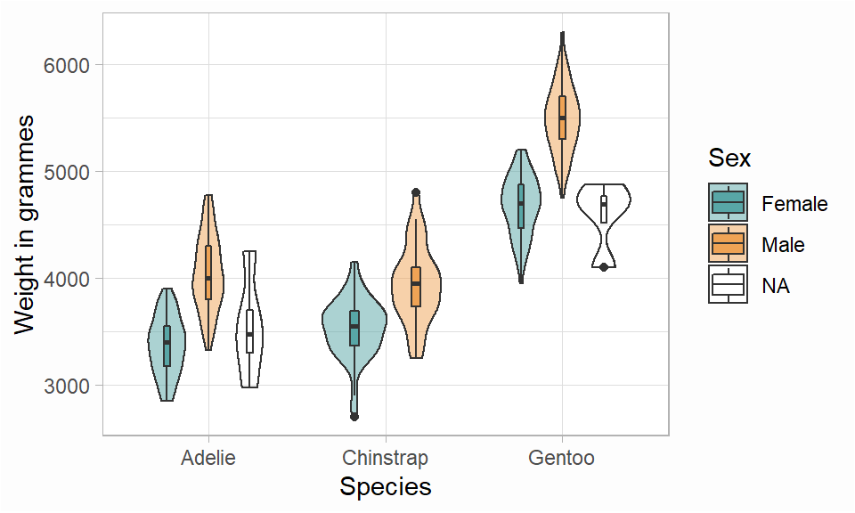

Figure 5. A violin plot of specimen weight by species and sex with inlaid boxplots

Except for the custom colours, you should already be able to make this plot. It’s pretty much the same as the one before, just with the elements filled by levels of the `sex` variable and with the `theme_light()` theme.

Have a go at making this plot using what you already know. The results will most likely look like this:

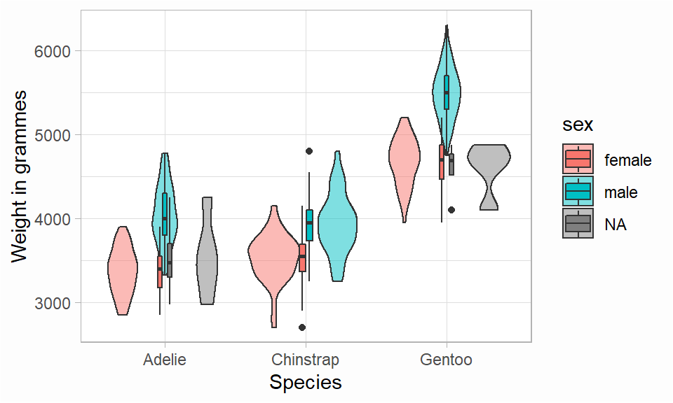

Figure 5b. A work-in-progress plot

That’s not quite it, is it? Sometimes, you need to tweak a few things to get the plot to look right. Here, we want to do three things:

1. Adjust the position of the violins and boxes to make them aligned
2. Pick custom fill colours
3. Capitalise the first letters of the legend text

We can do the first one using the `position=` argument that all `geoms` understand. There are several functions we can use to adjust both horizontal and vertical position of the `geoms` but let’s just talk about the most basic one, `position_dodge()`.

This function takes the `width=` argument, that specifies how much we want to nudge the given `geom` by along the x-axis. Try adding `position = position_dodge(width = 0.7)` to the boxplot later and see what happens.

OK, so the boxes are now further apart but they don’t quite align with the violins. To make them align, you can simply adjust the position of the violins in the same way. Try doing it now.

```r
palmerpenguins::penguins %>%
  ggplot2::ggplot(data = .,
                  aes(x = species, y = body_mass_g, fill = sex)) +
  geom_violin(alpha = .5, position = position_dodge(width = 0.7)) +
  geom_boxplot(width = 0.1, position = position_dodge(width = 0.7)) +
  labs(x = "Species", y = "Weight in grammes") +
  theme_light()
```

Nice!

All that’s left for us to do now is to change the colour scheme and adjust the legend text. We can do both of these by setting the fill scale manually using the `scale_fill_manual()` function.

The function takes several arguments but, in our case, we’re interested in three of them:

- `name=` takes a character string and sets the name for the scale which then gets printed as the legend title
- `lables=` takes a character vector with as many labels as there are levels of the variable. In our plot, we have 3 levels: Male, Female, and NA
- `values=` takes a character vector of colours, one for each level of the variable. Because one of our levels is `NA` (missing data), it’s colour can’t really be set so it doesn’t matter what colour you provide as the third one. You may as well give it an `NA`.

Feel free to pick your own colours but if you’re particularly fond of the ones in the plot above, they are `c("#58a6a6", "#efa355", NA)`. If you want to understand these colour codes, check out the gimme mo`R`! box below.

```r
palmerpenguins::penguins %>%
  ggplot2::ggplot(data = .,
                  aes(x = species, y = body_mass_g, fill = sex)) +
  geom_violin(alpha = .5, position = position_dodge(width = 0.7)) +
  geom_boxplot(width = 0.1, position = position_dodge(width = 0.7)) +
  labs(x = "Species", y = "Weight in grammes") +
  scale_fill_manual(
    name = "Sex", # change name in the legend
    labels = c("Female", "Male", NA), # change legend key
    values = c("#58a6a6", "#efa355", NA)) + # custom colours
  theme_light()
```

The values given to the colours are in the so-called hex-code. Each colour shown on the screen can be represented as a mixture of red, green and blue. Each of these three channels can be set to different intensity which then produces all the possible colour shades that most of us can see. The intensity is set using a two-digit [hexadecimal](https://en.wikipedia.org/wiki/Hexadecimal) number. This is a number system that has 16 digits instead of 10: 0, 1, 2, 3, 4, 5, 6, 7, 8, 9, a, b, c, d, e, f.

So each of the three colouor channels can be set to any number from 00 (no intensity) to ff (full intensity):

- `"#ff0000"` is red
- `"#00ff00"` is green
- `"#0000ff"` is blue
- `"#000000"` is black
- `"#ffffff"` is white

Have fun!

### Errorbar plot

OK, all of the plots we’ve made thus far were based on the datasets in their basic form. We didn’t have to do any data-wrangling.

Let’s now create a plot that needs a summary `tibble` – an errorbar plot like this:

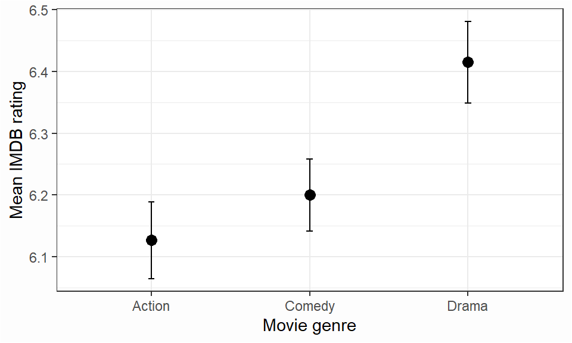

Figure 6. Errorbar plot of mean IMDB rating by movie genre. Error bars represent ±2 *SEM*.

The points in the plot represent mean IMDB rating per each of the three movie genres and the error bars range from −2×*SEM* to +2×*SEM* from the mean.

So, to create this plot, you need to give it a summarised `tibble` with mean rating and *SEM* per each of the three genres. There are quite a few more genres in the `movie_data` data set so before you summarise it, you need to only keep these three. Write the code to produce this summary `tibble` in the `errorbar-data` code chunk.

This is the kind of `tibble` you’re looking for:

```
## # A tibble: 3 x 3
##   genre  mean_rating     se
##   <chr>        <dbl>  <dbl>
## 1 Action        6.13 0.0311
## 2 Comedy        6.2  0.0292
## 3 Drama         6.42 0.0330
```

You need to `filter()`, `group_by()` and `summarise()` the data.

Filtering should only keep those row, for which `genre` is `"Drama"` or `"Action"`, or `"Comedy"`.

```r
movie_smry_plot <- movie_data %>%
  # filter genre to be drama OR action OR comedy
  dplyr::filter(
    .data = .,
    genre == "Drama" | genre == "Action" | genre == "Comedy") %>%
  dplyr::group_by(.data = ., genre) %>%
  dplyr::summarise(
    .data = .,
    mean_rating = mean(rating), # calculate mean rating
    se = sd(rating)/sqrt(n())) # and std. error of the mean
```

Instead of chaining OR (`|`) operators like this, you can use the `%in%` operator. It tests whether any of the elements in the vector to the left of it are present in the vector to the right of it.

So, instead of `genre == "Drama" | genre == "Action" | genre == "Comedy"`, you can just write `genre %in% c("Drama", "Action", "Comedy")`

Now that we have the `tibble` ready, we can push it to `ggplot2::ggplot()`.

This time round, we need to use the `geom_errorbar()` function to add a layer of errorbars before we add a layer of points. The function needs two arguments, both **mapped as aesthetics**: `ymin=`, which specifies there the lower end of the bars should be, and `ymax=`, which sets the upper end.

Try making the errorbar plot by completing the code in the `errorbar-plot` code chunk.

To do this, you will need a little maths thinking. We want the lower limit of the bars to be 2×*SEM* smaller that the mean and the upper limit to be 2×*SEM* bigger.

```r
movie_smry_plot %>%
  ggplot2::ggplot(data = ., aes(x = genre, y = mean_rating)) +
  geom_errorbar(
    # set lower and upper limits for error bars
    aes(ymin = mean_rating - 2 * se, # 2 SEM below them mean
        ymax = mean_rating + 2 * se), # 2 SEM above them mean
    width = .04) +
  geom_point(size = 3) + # make the points slightly bigger
  labs(x = "Movie genre", y = "Mean IMDB rating") +
  theme_bw()
```

That *is* a tasty plot!

There is actually an alternative way of making this plot that doesn’t require any data summarising before the data enters `ggplot2::ggplot()`. Instead, we can tell the plotting function to perform the summary for us. This is done with `stat_summary` layers instead of our `geom_` layers:

```r
movie_data %>%
  dplyr::filter(.data = ., genre %in% c("Drama", "Action", "Comedy")) %>%
  ggplot2::ggplot(data = ., aes(x = genre, y = rating)) +
  # fun.data= is used to set ymin- and ymax= of errorbars
  stat_summary(fun.data = ggplot2::mean_se, # mean_se returns a tibble
               geom = "errorbar", width = .04) +
  # fun= is used for the setting the y-values of points
  stat_summary(fun = mean, # fuction to transform the data is mean
               geom = "point", size = 3) + # these should be points
  labs(x = "Movie genre", y = "Mean IMDB rating") +
  theme_bw()
```

It really doesn’t matter which approach you choose. Just pick the one that makes most sense to you.

### Publication-quality groupped errorbar chart

Time to turn difficulty [all the way up to 11](https://www.youtube.com/watch?v=4xgx4k83zzc)[^3]

If you’ve made it this far you’re probably a massive glutton for punishment and, as such, will really enjoy the last task. It’s quite a treat!

Here is the kind of a grouped errorbar plot you may wll see in a published paper:

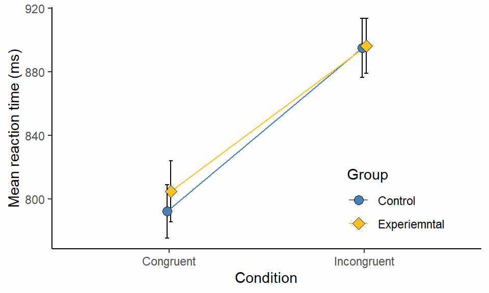

Figure 7. Mean performance on the Stroop task across conditions in Experimental vs Control group

Your final task is to try create this plot of the `stroop_data` data set, using the `showstopper` chunk with minimal guidance. To be able to do this, you will need to look up things on your own and learn how to use a few functions from examples and documentation you find online.

If you’re really keen, you can stop reading here and try your luck.

If you’d like some general hints and guidance this is what you need to do to create the plot:

1. Prepare the summary `tibble`. We’ve already made one very much like this when we made the summary table. You just need to adjust the grouping.
2. You should map a grouping variable onto the `group=` of `ggplot2::ggplot()`
3. You need three separate `geom_` layers: one for the errorbars, one for the lines, one for the points.
4. The position of all three `geoms` must be dodged by the same amount.
5. You need a custom x-axis to change the tick and axis labels. Look up `scale_x_discrete()`.
6. You need custom fill, colour, and shape, all of them with the same name and labels
7. You should change the theme.
8. Finally, you need to adjust the position of the legend

Good luck!

```r
# we can save output of position dodge so that we don't have to repeat
# the code each time
dodge <- position_dodge(.04)

stroop_data %>%
  dplyr::group_by(.data = ., group, condition) %>%
  dplyr::summarise(.data = ., mean_rt = mean(rt), se = sd(rt)/sqrt(n())) %>%
  # define grouping in base layer so that it gets passed down to geoms
  ggplot2::ggplot(data = .,
                  aes(x = condition, y = mean_rt, group = group)) +
  geom_errorbar(
    aes(ymin = mean_rt - 2 * se, ymax = mean_rt + 2 * se),
    width = .04, position=dodge) + # use the dodge object defined above
  geom_line(aes(colour = group), # colour lines by group
            position=dodge) + # use the same dodge object as above
  geom_point(aes(fill = group, shape = group),
             size=3, position=dodge) + # again, use the dodge object
  ylab("Mean reaction time (ms)") + # only change y-axis label here
  scale_x_discrete( # custom x-axis
    name = "Condition", # label changed here instead of labs
    labels = c("Congruent", "Incongruent")) + # axis tick labels
  # custom fill, colour, and shape, all must have the same name and labels
  scale_fill_manual(name = "Group", labels = c("Control", "Experiemntal"),
                    values = c("steelblue", "goldenrod1")) +
  scale_colour_manual(name = "Group", labels = c("Control", "Experiemntal"),
                      values = c("steelblue", "goldenrod1")) +
  scale_shape_manual(name = "Group", labels = c("Control", "Experiemntal"),
                     values = c(21, 23)) +
  theme_classic() + # classic theme
  theme(legend.position = c(.8, .2)) # 80% along x-asi, 20% along y-axis
```

OK, this was a lot!

Chances are, you haven’t managed to make all the plots and tables. If that’s the case, make sure you come back to this worksheet to get some more practice with `kableExtra` and `ggplot2`.

**Well done!**

[^1]: or you, like me, are a complete design control-freak and won’t rest till everything is just the way you want it… (Milan)
[^2]: Aye, that’s a real word, look it up! It’s a great word…
[^3]: Fun fact: “This is Spinal Tap”, the cult film that coined this expression is the only movie that has an IMDB rating out of 11. If you like rock and you haven’t seen the film, you absolutely must, it’s hilarious!